# 클린업 1주차 패키지

유경민

```r
setwd("C:/Users/ykm25/Desktop/P-SAT/2학기/패키지 과제/1주차패키지")

library(tidyverse)
library(data.table)
library(gridExtra)
library(reshape2)
library(lubridate)
library(magrittr)
```

# DATA 부르기

```r
train <- fread("train_NA.csv",
               header = TRUE,
               stringsAsFactors = FALSE,
               data.table = FALSE,
               encoding = "UTF-8"
)
```

# DATA 구조 확인

## 1-1. 데이터 기본 구조를 파악하고 데이터 개수개수, 변수 개수개수, 변수에 대한 간단한 설명을 해주세요.

```r
str(train)
```

```
## 'data.frame':    111497 obs. of  13 variables:
##  $ REG_YYMM    : int  201911 201911 201911 201911 201911 201911 201911 201911 201911 201911 ...
##  $ CARD_SIDO_NM: chr  "서울" "서울" "서울" "서울" ...
##  $ CARD_CCG_NM : chr  "강남구" "강남구" "강남구" "강남구" ...
##  $ STD_CLSS_NM : chr  "건강보조식품 소매업" "건강보조식품 소매업" "건강보조식품 소매업" "건강보조식품 소매업" ...
##  $ HOM_SIDO_NM : chr  "경기" "경기" "경기" "경기" ...
##  $ HOM_CCG_NM  : chr  "고양시 덕양구" "남양주시" "용인시 기흥구" "화성시" ...
##  $ AGE         : chr  "30s" "40s" "30s" "30s" ...
##  $ AGE_N       : num  37.2 41.2 36.7 30.2 36 ...
##  $ SEX_CTGO_CD : int  2 1 1 1 2 2 2 2 2 2 ...
##  $ FLC         : int  2 3 2 2 2 1 5 5 2 2 ...
##  $ CSTMR_CNT   : int  5 3 3 5 NA 3 7 4 20 3 ...
##  $ AMT         : int  120000 18000 810000 593000 345000 139000 922000 231000 913900 179000 ...
##  $ CNT         : int  6 3 3 6 6 3 7 4 20 3 ...
```

### 111497 obs와 13 variables로 이루어진 데이터 프레임이다.

```r
table(train$CARD_SIDO_NM)
```

```
##
##   서울
## 111497
```

### 서울시를 대상으로 한 데이터이다.

```r
table(train$REG_YYMM)
```

```
##
## 201911 201912 202001 202002
##  28576  29310  28404  25207
```

### 2019년 11월부터 2020년 2월까지의 기간동안 수집되었다.

```r
summary(train)
```

```
##     REG_YYMM      CARD_SIDO_NM       CARD_CCG_NM        STD_CLSS_NM
##  Min.   :201911   Length:111497      Length:111497      Length:111497
##  1st Qu.:201911   Class :character   Class :character   Class :character
##  Median :201912   Mode  :character   Mode  :character   Mode  :character
##  Mean   :201955
##  3rd Qu.:202001
##  Max.   :202002
##
##  HOM_SIDO_NM         HOM_CCG_NM            AGE                AGE_N
##  Length:111497      Length:111497      Length:111497      Min.   :10.00
##  Class :character   Class :character   Class :character   1st Qu.:31.27
##  Mode  :character   Mode  :character   Mode  :character   Median :41.86
##                                                           Mean   :42.59
##                                                           3rd Qu.:53.59
##                                                           Max.   :72.00
##
##   SEX_CTGO_CD         FLC          CSTMR_CNT             AMT
##  Min.   :1.000   Min.   :1.000   Min.   :    3.00   Min.   :     1000
##  1st Qu.:1.000   1st Qu.:2.000   1st Qu.:    5.00   1st Qu.:   126760
##  Median :1.000   Median :3.000   Median :   13.00   Median :   384000
##  Mean   :1.467   Mean   :2.779   Mean   :   84.85   Mean   :  2981637
##  3rd Qu.:2.000   3rd Qu.:4.000   3rd Qu.:   42.00   3rd Qu.:  1339800
##  Max.   :2.000   Max.   :5.000   Max.   :15035.00   Max.   :745067234
##                                  NA's   :20783
##       CNT
##  Min.   :    1.0
##  1st Qu.:    7.0
##  Median :   20.0
##  Mean   :  184.4
##  3rd Qu.:   70.0
##  Max.   :64596.0
##
```

### 수치형 변수의 분포를 확인

```r
colSums(is.na(train))
```

```
##     REG_YYMM CARD_SIDO_NM  CARD_CCG_NM  STD_CLSS_NM  HOM_SIDO_NM   HOM_CCG_NM
##            0            0            0            0            0            0
##          AGE        AGE_N  SEX_CTGO_CD          FLC    CSTMR_CNT          AMT
##            0            0            0            0        20783            0
##          CNT
##            0
```

### CSTMR_CNT에 결측치가 존재한다.

```r
head(train)
```

```
##   REG_YYMM CARD_SIDO_NM CARD_CCG_NM         STD_CLSS_NM HOM_SIDO_NM
## 1   201911         서울      강남구 건강보조식품 소매업        경기
## 2   201911         서울      강남구 건강보조식품 소매업        경기
## 3   201911         서울      강남구 건강보조식품 소매업        경기
## 4   201911         서울      강남구 건강보조식품 소매업        경기
## 5   201911         서울      강남구 건강보조식품 소매업        서울
## 6   201911         서울      강남구 건강보조식품 소매업        서울
##      HOM_CCG_NM AGE AGE_N SEX_CTGO_CD FLC CSTMR_CNT    AMT CNT
## 1 고양시 덕양구 30s 37.23           2   2         5 120000   6
## 2      남양주시 40s 41.25           1   3         3  18000   3
## 3 용인시 기흥구 30s 36.67           1   2         3 810000   3
## 4        화성시 30s 30.19           1   2         5 593000   6
## 5        강동구 30s 36.03           2   2        NA 345000   6
## 6        광진구 30s 34.76           2   1         3 139000   3
```

```r
tail(train)
```

```
##        REG_YYMM CARD_SIDO_NM CARD_CCG_NM             STD_CLSS_NM HOM_SIDO_NM
## 111492   202002         서울      중랑구 화장품 및 방향제 소매업        서울
## 111493   202002         서울      중랑구 화장품 및 방향제 소매업        서울
## 111494   202002         서울      중랑구 화장품 및 방향제 소매업        서울
## 111495   202002         서울      중랑구 화장품 및 방향제 소매업        서울
## 111496   202002         서울      중랑구 화장품 및 방향제 소매업        서울
## 111497   202002         서울      중랑구 화장품 및 방향제 소매업        서울
##        HOM_CCG_NM AGE AGE_N SEX_CTGO_CD FLC CSTMR_CNT     AMT CNT
## 111492     도봉구 30s 31.85           2   2         3 1023960   4
## 111493   동대문구 50s 54.01           1   4         9 1062700  16
## 111494   동대문구 50s 52.50           2   4        28  838500  34
## 111495     성북구 30s 32.38           1   2         6   69200   6
## 111496     성북구 40s 42.92           1   3         3   27000   3
## 111497     성북구 40s 42.97           2   3         3   77000   3
```

## 1-2. 범주형 변수이지만변수이지만, 수치형 변수로 읽혀진 변수들을 범주형 변수로 바꿔주세요.

```r
train %<>% mutate_at(vars(-c(CSTMR_CNT, AMT, CNT, AGE_N)), as.factor)
```

## 1-3-1번. 다음의 코드를 실행하세요.

```r
train2 <-train
```

## 1-3-2번. train2에 YEAR, MONTH 변수를 만드세요.

```r
ym = zoo::as.yearmon(as.character(train2$REG_YYMM), format="%Y%m")
train2 %<>% mutate(YEAR= year(ym), MONTH=month(ym))
```

## 1-3-3번. train2에 REG_YYMM 변수를 삭제하세요.

```r
train2 %<>% select(-REG_YYMM)
```

# 1-3-4번. train에대하여 YEAR, MONTH 변수를 만들고만들고, 범주형으로 바꾼 뒤, REG_YYMM 변수를 삭제하는 과정을 %>% 를 통해 한번의 코드로 실행하세요.

```r
train %<>% mutate(YEAR= year(ym), MONTH=month(ym)) %>%
  mutate_at(vars(c(YEAR, MONTH)), as.factor) %>%
  select(-REG_YYMM)

str(train)
```

```
## 'data.frame':    111497 obs. of  14 variables:
##  $ CARD_SIDO_NM: Factor w/ 1 level "서울": 1 1 1 1 1 1 1 1 1 1 ...
##  $ CARD_CCG_NM : Factor w/ 25 levels "강남구","강동구",..: 1 1 1 1 1 1 1 1 1 1 ...
##  $ STD_CLSS_NM : Factor w/ 39 levels "건강보조식품 소매업",..: 1 1 1 1 1 1 1 1 1 1 ...
##  $ HOM_SIDO_NM : Factor w/ 2 levels "경기","서울": 1 1 1 1 2 2 2 2 2 2 ...
##  $ HOM_CCG_NM  : Factor w/ 67 levels "가평군","강남구",..: 6 19 53 67 3 13 28 28 34 34 ...
##  $ AGE         : Factor w/ 7 levels "10s","20s","30s",..: 3 4 3 3 3 3 6 7 3 4 ...
##  $ AGE_N       : num  37.2 41.2 36.7 30.2 36 ...
##  $ SEX_CTGO_CD : Factor w/ 2 levels "1","2": 2 1 1 1 2 2 2 2 2 2 ...
##  $ FLC         : Factor w/ 5 levels "1","2","3","4",..: 2 3 2 2 2 1 5 5 2 2 ...
##  $ CSTMR_CNT   : int  5 3 3 5 NA 3 7 4 20 3 ...
##  $ AMT         : int  120000 18000 810000 593000 345000 139000 922000 231000 913900 179000 ...
##  $ CNT         : int  6 3 3 6 6 3 7 4 20 3 ...
##  $ YEAR        : Factor w/ 2 levels "2019","2020": 1 1 1 1 1 1 1 1 1 1 ...
##  $ MONTH       : Factor w/ 4 levels "1","2","11","12": 3 3 3 3 3 3 3 3 3 3 ...
```

## 1-4-1번. 범주형 변수들의 유니크한 범주 개수를 파악해보세요(하나씩 해보세요.)

```r
train$CARD_SIDO_NM %>% unique() %>% length()
```

```
## [1] 1
```

```r
train$CARD_CCG_NM %>% unique() %>% length()
```

```
## [1] 25
```

```r
train$STD_CLSS_NM %>% unique() %>% length()
```

```
## [1] 39
```

```r
train$HOM_SIDO_NM %>% unique() %>% length()
```

```
## [1] 2
```

```r
train$HOM_CCG_NM %>% unique() %>% length()
```

```
## [1] 67
```

```r
train$AGE  %>% unique() %>% length()
```

```
## [1] 7
```

```r
train$SEX_CTGO_CD %>% unique() %>% length()
```

```
## [1] 2
```

```r
train$FLC %>% unique() %>% length()
```

```
## [1] 5
```

```r
train$YEAR %>% unique() %>% length()
```

```
## [1] 2
```

```r
train$MONTH %>% unique() %>% length()
```

```
## [1] 4
```

## 1-4-2번. for구문을 통해 data.frame으로 저장해보세요.(저장한 뒤, console창에 출력해서 보여주세요)

```r
unique_df = data.frame(columns = colnames(train %>% select_if(is.factor)), uniq_count=NA)

for (i in 1:dim(unique_df)[1]){
  var = unique_df$columns[i]
  unique_df[i,"uniq_count"]= train %>% select(var) %>% unique() %>% nrow()
}; unique_df
```

```
## Note: Using an external vector in selections is ambiguous.
## i Use `all_of(var)` instead of `var` to silence this message.
## i See <https://tidyselect.r-lib.org/reference/faq-external-vector.html>.
```

```
##         columns uniq_count
## 1  CARD_SIDO_NM          1
## 2   CARD_CCG_NM         25
## 3   STD_CLSS_NM         39
## 4   HOM_SIDO_NM          2
## 5    HOM_CCG_NM         67
## 6           AGE          7
## 7   SEX_CTGO_CD          2
## 8           FLC          5
## 9          YEAR          2
## 10        MONTH          4
```

## 1-4-3번. 범주형 변수의 유니크한 범주를 세주는 함수(function)을 만든 뒤, apply를 통해 data.frame을 만들어 보세요.

```r
unique_function = function(col){
  count = col %>% unique() %>% length()
}

uniq_count = apply(train%>% select_if(is.factor), 2, unique_function);uniq_count
```

```
## CARD_SIDO_NM  CARD_CCG_NM  STD_CLSS_NM  HOM_SIDO_NM   HOM_CCG_NM          AGE
##            1           25           39            2           67            7
##  SEX_CTGO_CD          FLC         YEAR        MONTH
##            2            5            2            4
```

```r
data.frame(columns=names(uniq_count), uniq_count, row.names = 1:10 )
```

```
##         columns uniq_count
## 1  CARD_SIDO_NM          1
## 2   CARD_CCG_NM         25
## 3   STD_CLSS_NM         39
## 4   HOM_SIDO_NM          2
## 5    HOM_CCG_NM         67
## 6           AGE          7
## 7   SEX_CTGO_CD          2
## 8           FLC          5
## 9          YEAR          2
## 10        MONTH          4
```

## 1-4-4번. 1-4-2번, 1-4-3번을 통해 만든 data.frame을 다음과 같이 시각화해서 보여주세요.(최대한 비슷하게 그려주세요)

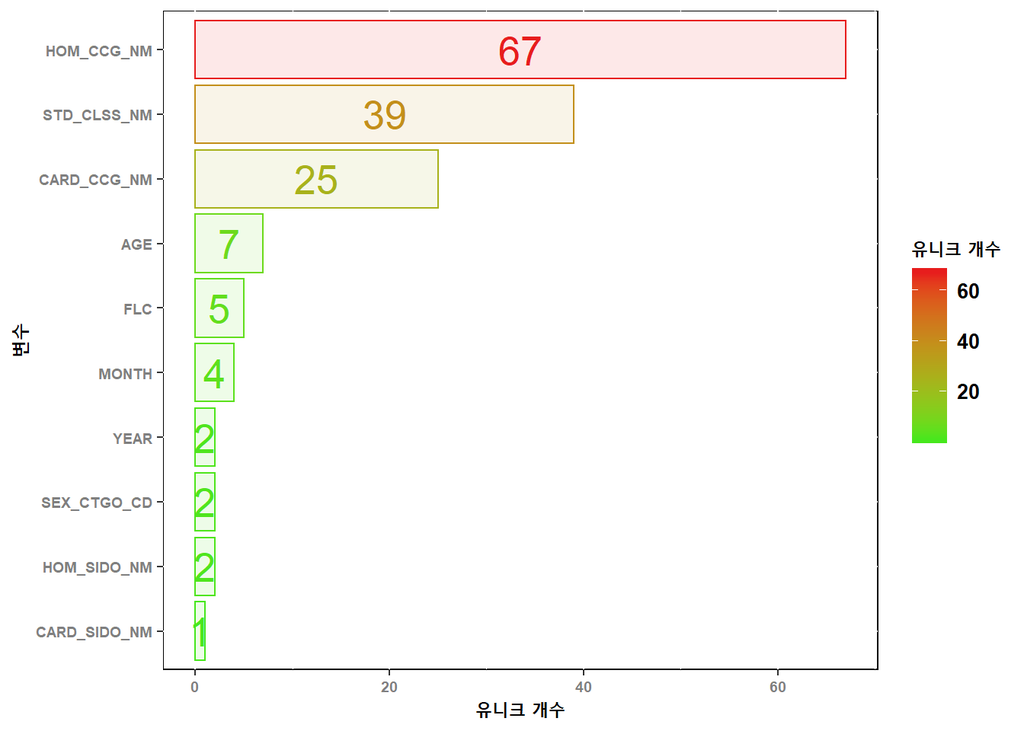

```r
ggplot(unique_df, aes(x=reorder(columns, uniq_count), y=uniq_count, fill=uniq_count, color=uniq_count))+
  geom_bar(stat="identity", alpha=0.1)+
  coord_flip() +
  theme(panel.background = element_rect(fill='white', color='black', linetype='solid'),
         axis.title.x=element_text(face="bold", size=10),
         axis.title.y=element_text(face="bold", size=10),
         plot.title=element_text(face="bold", size=10),
         axis.text.x = element_text(size=7, face="bold", colour = "grey50"),
         axis.text.y = element_text(size=7, face="bold", colour = "grey50"),
         legend.title=element_text(face="bold", size=10),
         legend.text = element_text(face="bold", size=10))+
  scale_fill_gradient(
    high = "#E71D1D",
    low = "#47E71D",
    space = "Lab",
    na.value = "grey50",
    guide = "colourbar",
    aesthetics = c("fill","color"))+
  labs(x="변수", y="유니크 개수", fill="유니크 개수" )+
  geom_text(aes(x=columns, y=uniq_count,label=uniq_count),size=7, position = position_stack(vjust = .5))+
  guides(color = FALSE)
```

## 1-4-5번. 범주형 변수의 범주 유니크 개수 파악 결과를 보고, 특정 변수를 삭제해도 될지 여부를 간단하게 설명해주세요.

### CARD_SIDO_NM은 level이 1으로 모든 row에 대해 동일한 값을 가진다. 따라서 경향을 파악하는데에 도움이 되지 않기에 삭제한다.

## 1-5-1번. 모든 변수들의 결측치결측치(NA) 개수를 확인해 보세요.

```r
na_count=colSums(is.na(train))
na_df = data.frame(columns=colnames(train), na_count, row.names = 1:length(na_count));na_df
```

```
##         columns na_count
## 1  CARD_SIDO_NM        0
## 2   CARD_CCG_NM        0
## 3   STD_CLSS_NM        0
## 4   HOM_SIDO_NM        0
## 5    HOM_CCG_NM        0
## 6           AGE        0
## 7         AGE_N        0
## 8   SEX_CTGO_CD        0
## 9           FLC        0
## 10    CSTMR_CNT    20783
## 11          AMT        0
## 12          CNT        0
## 13         YEAR        0
## 14        MONTH        0
```

## 1-5-2번. 1-4-4번과 동일하게 다음과 같이 시각화 해주세요.

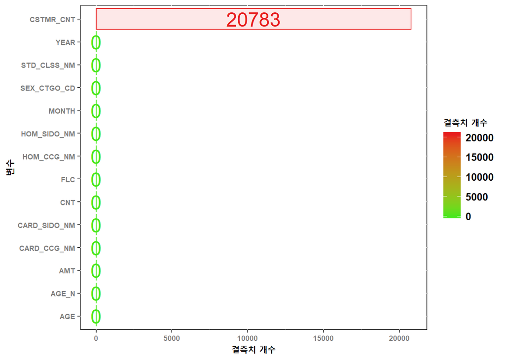

```r
ggplot(na_df, aes(x=reorder(columns, na_count), y=na_count, fill=na_count, color=na_count))+
  geom_bar(stat="identity", alpha=0.1)+
  coord_flip() +
  theme(panel.background = element_rect(fill='white', color='black', linetype='solid'),
         axis.title.x=element_text(face="bold", size=10),
         axis.title.y=element_text(face="bold", size=10),
         plot.title=element_text(face="bold", size=10),
         axis.text.x = element_text(size=7, face="bold", colour = "grey50"),
         axis.text.y = element_text(size=7, face="bold", colour = "grey50"),
         legend.title=element_text(face="bold", size=10),
         legend.text = element_text(face="bold", size=10))+
  scale_fill_gradient(
    high = "#E71D1D",
    low = "#47E71D",
    space = "Lab",
    na.value = "grey50",
    guide = "colourbar",
    aesthetics = c("fill","color"))+
  labs(x="변수", y="결측치 개수", fill="결측치 개수" )+
  geom_text(aes(label=na_count),size=7,position = position_stack(vjust = .5))+
  guides(color = FALSE)
```

## 2-1번. 다음 코드를 실행하세요.

```r
train_mean = train
train_random = train
train_mode = train
```

## 2-2번. train_mean의 CSTMR_CNT변수의 NA값들을 평균 대체(Mean imputation) 방법으로 대체해주세요.

```r
train_mean[is.na(train_mean$CSTMR_CNT==T),"CSTMR_CNT"] = mean(train_mean$CSTMR_CNT, na.rm=T)
```

## 2-3번. train_random의 CSTMR_CNT변수의 NA값들을 무작위 대체(Random imputation) 방법으로 대체해주세요.

```r
q = quantile(train_random$CSTMR_CNT, probs=c(0.25, 0.75), na.rm=T)
train_random[is.na(train_random$CSTMR_CNT==T),"CSTMR_CNT"] = runif(sum(is.na(train_random$CSTMR_CNT)), q[[1]], q[[2]])
```

## 2-4번. train_mode의 CSTMR_CNT변수의 NA값들을 최빈값 대체대체(Mode imputation) 방법으로 대체해주세요.

```r
getmode <- function(v) {
  uniqv <- unique(v)
  if( sum(is.na(uniqv)) == 1){
    uniqv = uniqv[-which(is.na(uniqv))]
  }
  uniqv[which.max(tabulate(match(v, uniqv)))]
}

train_mode[is.na(train_mode$CSTMR_CNT==T),"CSTMR_CNT"] = getmode(train_mode$CSTMR_CNT)
```

## 2-5번. 기존 데이터(train), 평균대체(train_mean), 무작위대체(train_random), 최빈값대체(train_mode)의 각각의 CSTMR_CNT 변수의 평균, 분산을 비교하고 해석해주세요.

```r
dat = list(train, train_mean, train_random, train_mode)
data.frame(Method = c("Original", "Mean", "Random", "Mode"),
           Mean = unlist(lapply(dat, function(dat){dat$CSTMR_CNT %>% mean(na.rm=T)})),
           Variance = unlist(lapply(dat, function(dat){dat$CSTMR_CNT %>% var(na.rm=T)})))
```

```
##     Method     Mean Variance
## 1 Original 84.85064 147903.4
## 2     Mean 84.85064 120334.0
## 3   Random 73.43929 120923.6
## 4     Mode 69.59371 121350.0
```

### 결측치 대체한 데이터의 분산이 결측치가 있는 데이터보다 작다. 평균 대체한 경우 기존 데이터의 평균 값이 유지된다. 랜덤, 최빈값 대체의 경우 평균 값이 기존 데이터와 차이가 있다.

## 2-6번. 다음과 같이 결과를 시각화를 통해 보여주세요.

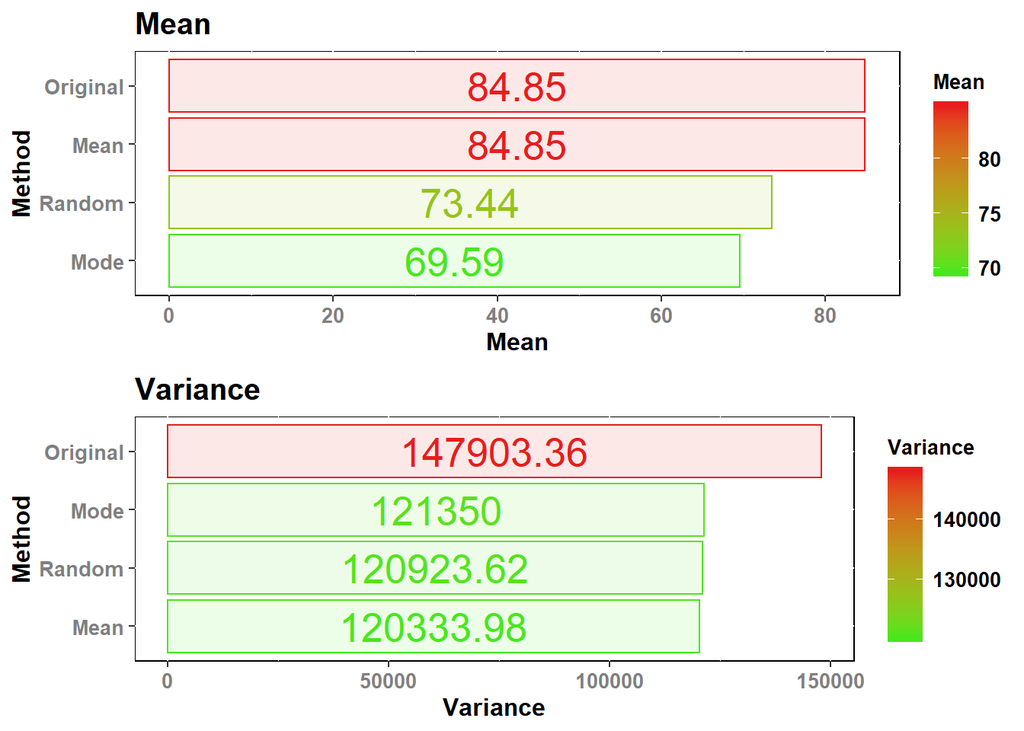

```r
imput_df = data.frame(Method = c("Original", "Mean", "Random", "Mode"),
           Mean = unlist(lapply(dat, function(dat){dat$CSTMR_CNT %>% mean(na.rm=T) %>% round(digits=2)})),
           Variance = unlist(lapply(dat, function(dat){dat$CSTMR_CNT %>% var(na.rm=T)%>% round(digits=2)})))

p1 = ggplot(imput_df, aes(x=reorder(Method, Mean), y=Mean, fill=Mean, color=Mean))+
  geom_bar(stat="identity",alpha=0.1)+
  coord_flip()+
  theme(panel.background = element_rect(fill='white', color='black', linetype='solid'),
        axis.title.x=element_text(face="bold", size=12),
        axis.title.y=element_text(face="bold", size=12),
        plot.title=element_text(face="bold", size=15),
        axis.text.x = element_text(size=10, face="bold", colour = "grey50"),
        axis.text.y = element_text(size=10, face="bold", colour = "grey50"),
        legend.title=element_text(face="bold", size=10),
        legend.text = element_text(face="bold", size=10))+
  scale_fill_gradient(
    high = "#E71D1D",
    low = "#47E71D",
    space = "Lab",
    na.value = "grey50",
    guide = "colourbar",
    aesthetics = c("fill","color"))+
    labs(x="Method", y="Mean", title= "Mean")+
    geom_text(aes(label=Mean),size=7, position = position_stack(vjust = .5))

p2 = ggplot(imput_df, aes(x=reorder(Method, Variance), y=Variance, fill=Variance, color=Variance))+
  geom_bar(stat="identity",alpha=0.1)+
  coord_flip()+
  theme(panel.background = element_rect(fill='white', color='black', linetype='solid'),
        axis.title.x=element_text(face="bold", size=12),
        axis.title.y=element_text(face="bold", size=12),
        plot.title=element_text(face="bold", size=15),
        axis.text.x = element_text(size=10, face="bold", colour = "grey50"),
        axis.text.y = element_text(size=10, face="bold", colour = "grey50"),
        legend.title=element_text(face="bold", size=10),
        legend.text = element_text(face="bold", size=10))+
  scale_fill_gradient(
    high = "#E71D1D",
    low = "#47E71D",
    space = "Lab",
    na.value = "grey50",
    guide = "colourbar",
    aesthetics = c("fill","color"))+
  labs(x="Method", y="Variance", title= "Variance")+
  geom_text(aes(label=Variance),size=7, position = position_stack(vjust = .5))

gridExtra::grid.arrange(p1, p2, nrow=2)
```

# 시각화 파티

## 3-0-1번. 3번.txt 코드를 실행하세요

```r
rm(list = ls())
data <- fread("train.csv",
              header = T,
              stringsAsFactors = F,
              data.table = F,
              encoding = "UTF-8")
str(data)
```

```
## 'data.frame':    111497 obs. of  13 variables:
##  $ CARD_CCG_NM: chr  "강남구" "강남구" "강남구" "강남구" ...
##  $ STD_CLSS_NM: chr  "건강보조식품 소매업" "건강보조식품 소매업" "건강보조식품 소매업" "건강보조식품 소매업" ...
##  $ HOM_SIDO_NM: chr  "경기" "경기" "경기" "경기" ...
##  $ HOM_CCG_NM : chr  "고양시 덕양구" "남양주시" "용인시 기흥구" "화성시" ...
##  $ AGE        : chr  "30s" "40s" "30s" "30s" ...
##  $ AGE_N      : num  37.2 41.2 36.7 30.2 36 ...
##  $ SEX_CTGO_CD: int  2 1 1 1 2 2 2 2 2 2 ...
##  $ FLC        : int  2 3 2 2 2 1 5 5 2 2 ...
##  $ CSTMR_CNT  : int  5 3 3 5 6 3 7 4 20 3 ...
##  $ AMT        : int  120000 18000 810000 593000 345000 139000 922000 231000 913900 179000 ...
##  $ CNT        : int  6 3 3 6 6 3 7 4 20 3 ...
##  $ YEAR       : int  2019 2019 2019 2019 2019 2019 2019 2019 2019 2019 ...
##  $ MONTH      : int  11 11 11 11 11 11 11 11 11 11 ...
```

## 3-0-2번. 1-2번과 동일하게 범주형 변수이지만, 수치형 변수로 읽혀진 변수들을 범주형 변수로 바꿔주세요.

```r
data %<>% mutate_at(vars(-c(CSTMR_CNT, AMT, CNT, AGE_N)), as.factor)
```

## 3-1-1번. 월별 카드 사용 건수에 따른 나이, 성별 비율 파악하기위해 다음과 같이 시각화 그래프를 그려주세요.

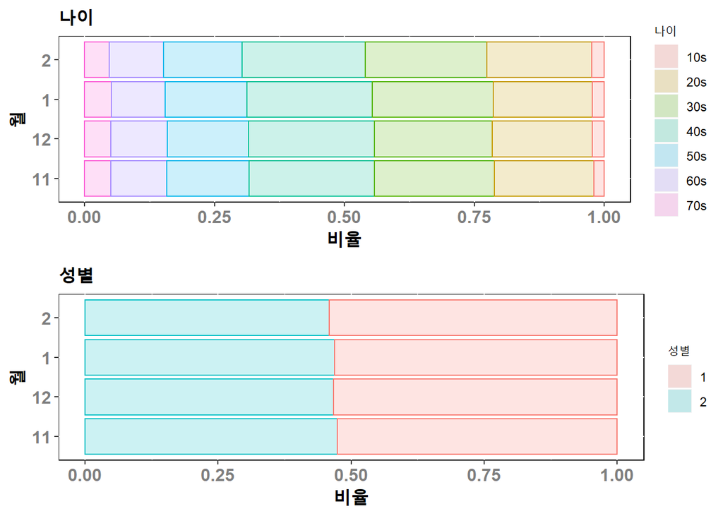

```r
data$MONTH %<>% factor(levels=c("11", "12", "1", "2"))

age_plot = ggplot(data, aes(x=MONTH, fill=AGE, color=AGE))+
  geom_bar(position='fill', alpha=0.2)+
  coord_flip()+
  theme(panel.background = element_rect(fill='white', color='black', linetype='solid'),
        axis.title.x=element_text(face="bold", size=15),
        axis.title.y=element_text(face="bold", size=15),
        plot.title=element_text(face="bold", size=15),
        axis.text.x = element_text(size=12, face="bold", colour = "grey50"),
        axis.text.y = element_text(size=12, face="bold", colour = "grey50"))+
  labs(x="월", y="비율", title="나이", fill="나이")+
  guides(color = FALSE)

sex_plot = ggplot(data, aes(x=MONTH, fill=SEX_CTGO_CD, color=SEX_CTGO_CD))+
  geom_bar(position='fill', alpha=0.2)+
  coord_flip()+
  theme(panel.background = element_rect(fill='white', color='black', linetype='solid'),
        axis.title.x=element_text(face="bold", size=15),
        axis.title.y=element_text(face="bold", size=15),
        plot.title=element_text(face="bold", size=15),
        axis.text.x = element_text(size=12, face="bold", colour = "grey50"),
        axis.text.y = element_text(size=12, face="bold", colour = "grey50"))+
  labs(x="월", y="비율", title="성별", fill="성별")+
  guides(color = FALSE)

gridExtra::grid.arrange(age_plot, sex_plot)
```

## 3-2-1번. 월별, 이용 지역 별로 카드 결제 횟수의 변화의 흐름을 보기 위해 다음과 같이 시각화 해주세요.

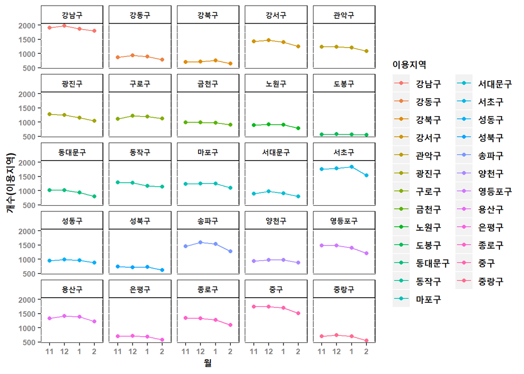

```r
data %>%
  group_by(CARD_CCG_NM, MONTH) %>%
  summarise(count=n()) %>%
  ggplot(aes(x=MONTH, y=count, color=CARD_CCG_NM, group=1))+
  geom_line()+
  geom_point()+
  facet_wrap(~CARD_CCG_NM, ncol=5)+
  theme(panel.background = element_rect(fill='white', color='black', linetype='solid'),
        axis.title.x=element_text(face="bold", size=10),
        axis.title.y=element_text(face="bold", size=10),
        plot.title=element_text(face="bold", size=10),
        axis.text.x = element_text(size=7, face="bold", colour = "grey50"),
        axis.text.y = element_text(size=7, face="bold", colour = "grey50"),
        legend.title=element_text(face="bold", size=10),
        legend.text = element_text(face="bold", size=10),
        strip.background = element_rect(fill="white", color="black"),
        strip.text = element_text(face="bold"))+
  labs(x="월", y="개수(이용지역)", color="이용지역")
```

## 3-2-2번. 시각화 결과에 대한 해석을 간략하게 해주세요.

### 구별 카드 사용량의 월별 흐름은 크게 변화지 않고 유지되는 경향을 보인다. 강남구, 서초구, 송파구, 영등포구, 중구의 카드 사용량은 다른구에 비해 높은 수준을 보인다. 반면 강동구, 강북구, 노원구, 도봉구, 은평구, 중랑구의 경우 다른 구에 비해 낮은 수준을 보인다. 모든 구에서 전반적으로 2월의 결제횟수가 적은데 이것이 실제로 적은 것인지 2월이 다른 달에 비해 짧기 때문인지 확인을 해보아야할 것 같다.

## 3-2-3번. 나이별, 평균이용건수와 평균 이용 고객수를 다음과 같이 시각화 해주세요.

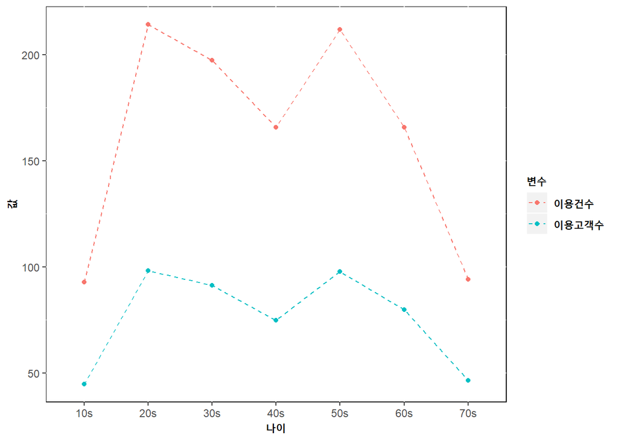

```r
data %>%
  group_by(AGE) %>%
  summarise(이용건수=mean(CNT), 이용고객수=mean(CSTMR_CNT)) %>%
  gather(key,value, c(이용건수, 이용고객수)) %>%
  ggplot(aes(x=AGE, y=value, color=key, group=key))+
  geom_point()+
  geom_line(linetype = "dashed")+
  theme(panel.background = element_rect(fill='white', color='black', linetype='solid'),
        axis.title.x=element_text(face="bold", size=10),
        axis.title.y=element_text(face="bold", size=10),
        legend.title=element_text(face="bold", size=10),
        legend.text = element_text(face="bold", size=10),
        strip.background = element_rect(fill="white", color="black"),
        strip.text = element_text(face="bold"))+
  labs(x="나이", y="값", color="변수")
```

## 3-3-1번. 수치형 변수들의 다중 공선성을 보기 위해 Correlation plot을 다음과 같이 그려주세요.

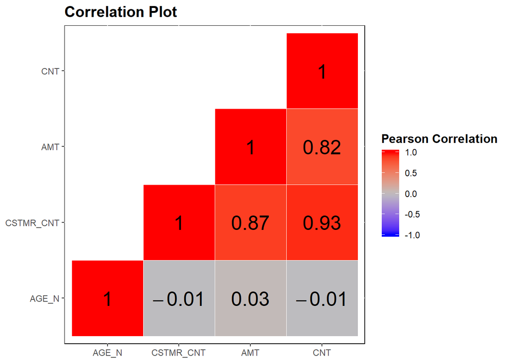

```r
cor_mat = cor(data %>% select_if(is.numeric))
cor_mat[upper.tri(cor_mat)] = NA
melted_cormat = melt(cor_mat, na.rm=T)

ggplot(melted_cormat, aes(Var1, Var2, fill=value))+
  geom_tile(color="white")+
  scale_fill_gradient2(low = "blue", high = "red", mid = "grey",
                       midpoint = 0, limit = c(-1,1), space = "Lab",
                       name="Pearson Correlation")+
  theme(panel.background = element_rect(fill='white', color='black', linetype='solid'),
        plot.title=element_text(face="bold", size=15),
        axis.title.x=element_blank(),
        axis.title.y=element_blank(),
        legend.title=element_text(face="bold", size=12))+
  labs(title="Correlation Plot")+
  geom_text(aes(label=round(value,2),size=7, vjust="center"), parse=T, size=7)
```

## 3-3-2번. 시각화 결과에 대한 해석을 간략하게 해주세요.

### AMT와 CSTMR_CNT, CNT와 CSTMR_CNT, CNT와 AMTs는 0.9 내외의 높은 상관관계를 보인다. Y인 이용금액과 상관관계가 높은 변수는 이용고객수, 이용건수이다. 이용고객수는 이용 건수와 높은 상관관계를 보인다.